# REAME: SARS-CoV-2 sequence submission process

#### GenBank submission info

1. Go to you NCBI Submissions portal > GenBank > New Submission
2. Under Submission Type > What do your sequences contain? Selection “SARS-CoV2, Influenza…” then for Which virus? Also select “SARS-CoV-2.” You can leave the submission title blank, but I fill in with the batch number in case I need to quickly reference which set of samples were included
3. Submitter Information is the same as for other NCBI submissions
4. Under sequencing technology select either “Illumina” for an batch of MiSeq or NextSeq samples, or “Other” if the batch is of assemblies from nanopore data (then put Oxford Nanopore in the field that appears). Then select assembled sequences
   - For Assembly information for Illumina data put minimap2 v.2.1, and iVar v.1.3.1
   - For Assembly information Nanopore assemblies put Arctic MinION JAN-2020
5. Under Sequences, select “release immediately following processing”
6. Then upload the fasta file you generated (GenBank doesn't accept dashes and you need to add the NCBI project number so GenBank adds it to the right project - code has been developed to do this as well)
7. A warning will pop up regarding N's and request to answer the question 'What do the internal NNN's represent?'. Fill in with 'A region of estimated length between the sequenced regions based on an alignment to similar sequences or genome"' and click 'continue'
8. Sequence processing: 'During processing, should NCBI remove sequences with errors and process the rest?". Depending on where we are against historic data either select 'yes' - Genbank will remove these from your submission and release the rest. The final Rscript will pull the metadata for the rejected samples to add to the 'ONGOING_submissions" tab". If you select 'no' then you will go back and forth with GenBank with coverage information etc.
9. Select 'None of these' for naming convention
10. Under the “Source Modifiers” tab you will upload your GenBank metadata tsv file
11. Under References you will List: Laura Bankers, Molly C. Hetherington-Rauth, Diana Ir, Alexandria Rossheim, Michael A. Martin, Mandy Waters, Shannon R. Matzinger, Sarah Elizabeth Totten, Emily A. Travanty – If names are not correct, please change them in the gisaid template section of the submissions google sheet, so that they are up to date.
    - You have to manually put these in the first time and then you can select and apply this list for later submissions
12. Then select “Unpublished” and then continue (can leave the rest of the boxes blank)
13. Under Review and Submit, make sure everything looks correct, then submit

### Detailed instructions for running R code

The objective of this code is to automate the creation of metadata tables for GISAID, NCBI Biosample, NCBI SRA, NCBI Genbank, and data for CDPHE tracking (all public IDs linked). This section of the document will outline the following items:

1. Installing R version 4 on GCP VM with Linux Ubuntu 18.04
2. Preparing the scripts and installing packages
3. Executing the R scripts
   - gisaid_ncbi_biosample_metadata_formatting.R
   - ncbi_sra_metadata_formatting.R
   - ncbi_genbank_metadata_formatting.R
   - submission_completed_metadata.R

I put all my metadata files (both those required as inputs and written out from these scripts) for a batch of uploads in a single directory, so the working directory is always the same.

### Installing R

#### Overview

You will need at least R version 4 to load the packages used in these scripts. Instructions are outlined (in tabs) for users who will be installing R for the first time as well as those who have a previous version of R already installed. NOTE: running sudo apt update alone will not update R to the version needed.

#### First R install

Click [here](https://www.digitalocean.com/community/tutorials/how-to-install-r-on-ubuntu-18-04-quickstart) to go to page with instuctions, which are also outlined below. The code below assumes you are running Ubuntu 18.04. You will need a different repository file if you are running a different version. This repository file will install regardless of your version and then will throw errors / won't update when you install a different version.

```bash
# Step 1 — Add GPG Key
# Logged into your Ubuntu 18.04 server as a sudo non-root user, add the relevant GPG key.
sudo apt-key adv --keyserver keyserver.ubuntu.com --recv-keys E298A3A825C0D65DFD57CBB651716619E084DAB9

# Step 2 — Add the R Repository
sudo add-apt-repository 'deb https://cloud.r-project.org/bin/linux/ubuntu bionic-cran40/'
    # If you’re not using 18.04, find the relevant repository from the R Project Ubuntu list, named for each release.

# Step 3 — Update Package Lists
sudo apt update

# Step 4 — Install R
sudo apt install r-base
    # If prompted to confirm installation, press y to continue.

# Step 5 — Test Install
# Start R’s interactive shell as root.
sudo -i R
```

You should see something like:

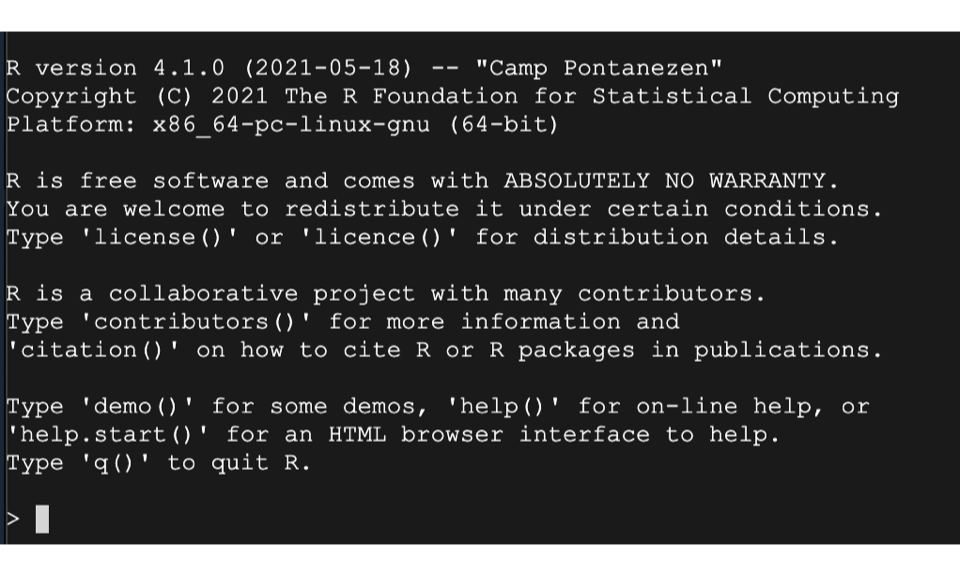

#### Uninstall R and update

Installing base R on 18.04 will install R version 3.5. If you have R < 4.0 you will need to uninstall R and reinstall R version 4. [Here](https://genomespot.blogspot.com/2020/06/installing-r-40-on-ubuntu-1804.html) is a link to instructions to uninstall older versions of R and then install version 4 (same as previous tab). These instructions are also below.

Uninstalling old version of R

```bash
# Step 1 - Make sure you have these dependancies installed. If you don't, you're going to have trouble installing any R packages like R curl, tidyverse, devtools, etc
sudo apt install libssl-dev libcurl4-openssl-dev libxml2-dev

#Step 2 - Remove any existing R install.
sudo apt remove r-base* --purge

# Step 3 - Remove any remaining packages. It's better to install them "fresh". They will be in locations like /home/user/R/R-3.6.6 and /usr/lib/R/library/

# Step 4 - Remove any existing entry for R in the etc/apt/sources.list to install an older R version.
sudo nano /etc/apt/sources.list
# For example you might have something like this:
# deb https://cloud.r-project.org/bin/linux/ubuntu bionic-cran35/
```

Now you can install R version 4

```bash
# Step 1 — Add GPG Key
# Logged into your Ubuntu 18.04 server as a sudo non-root user, add the relevant GPG key.
sudo apt-key adv --keyserver keyserver.ubuntu.com --recv-keys E298A3A825C0D65DFD57CBB651716619E084DAB9

# Step 2 — Add the R Repository
sudo add-apt-repository 'deb https://cloud.r-project.org/bin/linux/ubuntu bionic-cran40/'
    # If you’re not using 18.04, find the relevant repository from the R Project Ubuntu list, named for each release.

# Step 3 — Update Package Lists
sudo apt update

# Step 4 — Install R
sudo apt install r-base
    # If prompted to confirm installation, press y to continue.

# Step 5 — Test Install
# Start R’s interactive shell as root.
sudo -i R
```

You should see something like:

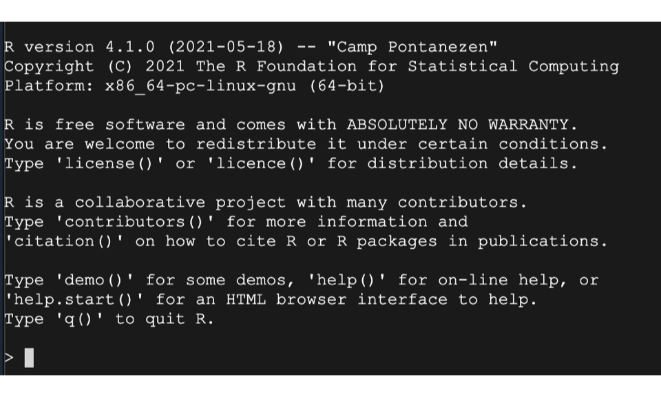

### Preparing script and installing packages

#### Prep scripts

Outlined here is instructions to make the R script executable on your VM and load necessary packages. First step is to clone the R scripts to your VM from the CDPHE Github [link](https://github.com/CDPHE/seq-submission-metadata-R).

Now make the R scripts executable (for some reason R scripts do not default as executable)

```bash
chmod +x gisaid_ncbi_biosample_metadata_formatting.R
```

Now install the packages as outlined in the 'Install packages' tab.

#### Installing packages

A few different packages are needed to run these scripts. The individual scripts will call the packages they need, but they must be installed on your VM first.

```bash
# Open an R session from your VM terminal
R

# Within your R environment run the following commands
if (packageVersion("devtools") < 1.6) {
  install.packages("devtools")
}
devtools::install_github("hadley/lazyeval")
devtools::install_github("hadley/dplyr")
devtools::install_github("hadley/plyr")
devtools::install_github("r-lib/cpp11")
install.packages("tidyr")
install.packages('optparse')
install.packages('stringr')
install.packages('tibble')

# devtools took a couple mins to load, this is normal

# Close R
quit()
```

Now you're ready to run the script R scripts

### GISAID and NCBI Biosample

#### Useage

**Script name:** gisaid_ncbi_biosample_metadata_formatting.R  
**Input files:** results_*.tsv (pull all files with this regex), rerun_samples_*.tsv, completed_submissions_*.tsv, ongoing_submissions*.tsv **Options / flags:** required to fill in all. The code will check spelling on the sequencing information and will error out if something is misspelled (options in #4 below)

1. -m | --metadata = path/to/seq_metadata/files # This also sets the working directory to write files
2. -f | --fasta_name = name_fasta_file_to_submit.fa # name of fasta file you will submit to GISAID
3. -s | --submitter_name = gisaid_submitter_name
4. -t | --seq_type = sequencing_type (Oxford Nanopore GridION, Illumina MiSeq, Illumina NextSeq)
5. -r | --rerun_file = path/to/rerun_file.tsv # tsv downloaded from List_of_bad_runs_and_waste_water_samples
6. -c | --completed_file = path/to/completed_file.tsv # tsv downloaded from submissions_and_compiled_metadata
7. -o | --ongoing_file = path/to/ongoing_file.tsv # tsv downloaded from submissions_and_compiled_metadata

**Example usage (short flags):**

```bash
# You need to type Rscript before your Rscript to run (Rscript gisaid_ncbi_biosample_metadata_formatting.R)
Rscript gisaid_ncbi_biosample_metadata_formatting.R -m /home/mandy_waters/test_metadata -f test_fasta.fa -s mandywaters -t "Oxford Nanopore GridION" -r /home/mandy_waters/rerun_samples_11Sep2021.tsv -c /home/mandy_waters/samples_already_submitted_11Sep2021.tsv -o /home/mandy_waters/ongoing_submissions_11Sep2021.tsv

# Strings with spaces need quotes
```

**Example usage (long flags):**

```bash
# You need to type Rscript before your Rscript to run (Rscript gisaid_ncbi_biosample_metadata_formatting.R)
Rscript gisaid_ncbi_biosample_metadata_formatting.R --metadata /home/mandy_waters/test_metadata -f test_fasta.fa --submitter_name mandywaters --seq_type "Oxford Nanopore GridION" --rerun_file /home/mandy_waters/rerun_samples_11Sep2021.tsv --completed_file /home/mandy_waters/samples_already_submitted_11Sep2021.tsv --ongoing_file /home/mandy_waters/ongoing_submissions_11Sep2021.tsv

# Strings with spaces need quotes
```

**Output to terminal:** Script prints the strings the user input for you to check. If you don't provide values for all flags then the script will error out and tell you which flag(s) are missing. The script will also error out if the sequence type name is misspelled. A warning and file will be printed / written that lists the accession name, coverage, and project number for samples that are missing a collection date or have a collection date prior to 2020. It will not error out, but will print this info and write it to a file for users to review. Another warning (will not error out) will be print if samples in your current batch have already been submitted or have been rerun. Samples will be dropped if they have already been submitted to GISAID or NCBI or are in the initial round of sequencing. It will print relevant information from the COMPLETED tab or ONGOING tab (if rejected by GenBank) in the metadata tracking excel sheet on Google Drive.

You should see something like the following regardless of short or long flag names

```r
Rscript /home/mandy_waters/scripts/git_repo/seq-submission-metadata-R/gisaid_ncbi_biosample_metadata_formatting.R -m ${cur_wd}/metadata -s mandy.waters -f ${batch}_gisaid_inital_upload.fa -t "Illumina NextSeq" -r /home/mandy_waters/Downloads/rerun_samples_17Oct2021.tsv -c /home/mandy_waters/Downloads/completed_submissions_17Oct2021.tsv -o /home/mandy_waters/Downloads/ongoing_submissions_17Oct2021.tsv

INPUT FILES AND FLAGS:

metadata path:
/home/mandy_waters/batch19_submit/metadata

name of fasta file to submit to GISAID:
batch19_gisaid_inital_upload.fa

submitter name for GISAID:
mandy.waters

sequencing type:
Illumina NextSeq

name of rerun file:
/home/mandy_waters/Downloads/rerun_samples_17Oct2021.tsv

name of completed submissions file:
/home/mandy_waters/Downloads/completed_submissions_17Oct2021.tsv

name of ongoing submissions file:
/home/mandy_waters/Downloads/ongoing_submissions_17Oct2021.tsv

SURVEILLANCE:
results.tsv files DO NOT have surveillance data


BAD NOODLES:
WARNING: the samples below have been submitted under multiple projects.  If you are processing the project in 'first_run' these samples will be removed from the dataset:
 accession_id   first_run     re_run
   2101678415 COVMIN_0195 NEXSEQ_050
   2101648947  NEXSEQ_046 NEXSEQ_050
   2101649102  NEXSEQ_046 NEXSEQ_050
   2101649021  NEXSEQ_046 NEXSEQ_050
   2101649115  NEXSEQ_046 NEXSEQ_050
   2101648944  NEXSEQ_046 NEXSEQ_050
   2101648933  NEXSEQ_046 NEXSEQ_050
   2101648926  NEXSEQ_046 NEXSEQ_050
   2101649116  NEXSEQ_046 NEXSEQ_050
   2101649013  NEXSEQ_046 NEXSEQ_050
   2101649118  NEXSEQ_046 NEXSEQ_050
   2101649106  NEXSEQ_046 NEXSEQ_050
   2101649220  NEXSEQ_046 NEXSEQ_050
   2101649000  NEXSEQ_046 NEXSEQ_050
   2101648994  NEXSEQ_046 NEXSEQ_050
   2101648987  NEXSEQ_046 NEXSEQ_050

FINISHED! Please check warnings and output files
```

**Output files:**

1. GISAID formatted file: gisaid_submission_date_metadata.csv (e.g. gisaid_submission_2021-07-03_metadata.csv)
2. NCBI Biosample formatted file: ncbi_biosample_submission_date_metadata.tsv (e.g. ncbi_biosample_submission_2021-07-03_metadata.tsv)
3. File to convert current fasta names to GISAID and GenBank format (fasta_rename_accession_to_gisaid_id.csv)
4. CONDITIONAL: Missing collection date only writes this if samples are missing a collection date (e.g. samples_missing_collection_date_2021-07-03.tsv)
5. CONDITIONAL: Collection date before 2020 only writes if samples collection date is before 2020 (e.g. samples_wrong_collection_date_2021-09-11.tsv)
6. CONDITIONAL: samples that have been rerun are listed if the accessions in your batch match accessions listed in the rerun file (e.g. samples_rerun_2021-09-11.tsv)
7. CONDITIONAL: samples that have already been submitted under a previous project (e.g. samples_already_submitted_2021-09-11.tsv)

I use the following awk command to replace the accession IDs in the fasta with GISAID accepted names. These samples have been run through all the steps through indel finder. After this the samples are run through VADR.

```bash
# Replace the accession IDs with GISAID IDs
# Takes in file output #3 from gisaid_ncbi_biosample_metadata_formatting.R
awk -F, 'FNR==NR {f2[$1]=$2;next} $2 in f2 {$2=f2[$2]}1' /path/to/fasta_rename_accession_to_gisaid_id.csv FS='>' OFS='>' input_fasta_post_indel_finder.fa > output_fasta_post_indel_finder_gisaid_format.fa
```